# Computational Skills and AI in Modern Biology

> y code when ai?

Jelmer Poelstra

CFAES Bioinformatics Core, The Ohio State University

College of Wooster · 19 November 2026

[figure not shown]

# Introduction

## Sequencing has become *much* cheaper

[figure not shown]

From genome.gov/sequencingcosts

## This has led to a data explosion

If sequencing one person’s genome takes **~600 million sequence “reads”**,  
how many Excel sheets would its data file fill?

```
@A00123:8:H5KTLDSXX:1:1101:10004:1000 1:N:0:ATCACG
GATTTGGGGTTCAAAGCAGTATCGATCAAATAGTAAATCCAAGCCCAATAAACCACTCTGACTGGCCGAATAGGGATATAGGCAACGACATGTGCGGCGACCCTTGCGACAGTGACGCTTTCGCCGTTGCCTAAACCTATTTGAAGGAGT
+
FFFFF:FFFFFFFFFFF,FFFFFFFFFFFFFFF:FFFFFFFFFF,FFFFFFFFF:::FFFF,FFFFFFF,FFF:FFF::FFFFFFFFFFFFFFFFFFFFFFFFFFFFFFFFFFFFFFFFFFFFFFFFFFFFFFFFFFFF:FFF:FFFFFF
@A00123:8:H5KTLDSXX:1:1101:10013:1000 1:N:0:ATCACG
CTTGCAAGGTCATCGACTTTAGGCTACCGTTAGCAAGTTCTCCGCAAGAATCAACAACTACAATGGCGCGTCGTGAATAACGCGACGGCTGAGACGAACGGCGCGTGAATGAAGCGCTTAAACAGCTCAGGAGCCAGTCCCCTACGTCGC
+
FFFFFFFFFF:FFFFFFFFFFFFFFFF,FFFFFFFFFFFFFFFFFFFFFFFFFF:FFF,F:F,F:FFFFFFFFFFFF:FFFFFFFFFFFFFFFFFF:F:FFFFFFFFFFFF:FFFFFFFFFFFFFFFFFFFFFFFFFFFFF:FFFFFFF,
@A00123:8:H5KTLDSXX:1:1101:10183:1000 1:N:0:ATCACG
CTAAAGACAATTACATAACATACACGTCAGCACGAAACTTGTTTCTTGCGTCGTAGCGGGACCCTCCATTGTTACTTATTAGGTTCTCGTTATGTCTCATAATCTCAGTGCTGGTGTGATAAGCAAACCACCCTACTGGCACGAAGTTCA
+
FF:FFFFFFFFFFFFFF:F:FFFFFFFFFFFFFFFFFFFFFFFFFFFFFFFFFFFFFFFFFFFFFF:FFFFFF:FFFFFFFFFFFFFFFFFFFFFFFFFFFFFFFF,FFFFFFFF:FFFFFFF,FFFFFFFFF:FFFFFFF:FFFFFFFF
@A00123:8:H5KTLDSXX:1:1101:10365:1000 1:N:0:ATCACG
ATGCATACGCCTTTACTTGCTGTGTCCACCCCATCGGACTGACATCTTTGTGAACCGACCCACATTTGACGGTACGCTACCGCAACGGTATGTGTTAATGGAACAGACTTGCTTATGTGGACGTTGTATAGGGATATTACGTTACGCGTT
+
FFFFF:FFFF:FFFFFFF,FFFFFF:FFFFF:FFFF,FFFF,FFFFFF,:FFFFFFFF,FFF:FFFFFF:FFFFF,FFFFFFFFFFFFFFFFFFFF,FFFFFFFFFFFFFF:FFFFFFFFFFFFFF:,FFFFFFF:FFFFFFFFFFFFF:
@A00123:8:H5KTLDSXX:1:1101:10753:1000 1:N:0:ATCACG
GGTCACGCAGAGGCGCGCCCTCCTGAAGTGCGTGGACACTCCTGTGATGCATGGTGTGCTTACTGGGATGAATGCGCCGCAAGTAGCAGGTCCCGGCGTGGATACCTGATAGATGGTGACTAGCATGTACAAGTAACCTTGTCTATTGAG
+
FFF:FFFFFF:FFFFFFF,FF:FFFF:FFF,FFFFF,FF:FFFF,F:FFF::FFFF,FF,FFFFFFFFFFF,,FFFFFFFFFFFFFFFFFFFFF:FFFF,FFFFFFFFFFFFFFFFFFFFFFFFFFFFFFFF:FFFFFFFFF:FFFF:F:
@A00123:8:H5KTLDSXX:1:1101:10980:1000 1:N:0:ATCACG
CCAGCGCGGTCAGTTCCATCACCCTAAGTAACCGAATAATAGGGACCTCAGGAGCTAGACGGGGACCTACAACTTTGCGGGAACCAAGTTTTTGCAGTAGTGACTAACGCCGGGAATTCCTCGATATATAGTTTGATAGCTGATACTTAT
+
F,FFFFFFFFF::FFFFFFFFFFFF:FFFFFFFFFFFF,FFFFFFFFFFF:FFFFFFFF:FFFFFFF,F,FFFFFFFFFFFFF,FFFF:FF:FFFF:FFF,FFFF,FFF:FFFFFFFFFFF:FFFF:FFFFFFFFFFF:,:FFFFF:FFF
@A00123:8:H5KTLDSXX:1:1101:11200:1000 1:N:0:ATCACG
CGGAGAGTTATGGAACAAGGACGCTGTCTGAGACTAGAAGCCAGAAGCTCCCCTATGCTGTCCGTCGTTGTTCCCGATGAAGACGTCTACTGATATGCTAGCAGAGCCAGTCTTAAAGCCTAGCGAACTTAATACCGTAGCTCAGAATTA
+
FFFFFFF:FFFFFFFFFFFFFFFFFFFFFF:FFFFFFFF,F,FFFFFFFFFFFFFFFFFFFFFFFFF:F,FFFFFFFFFFFFFF,FF:FFFFFFFFFFFFFFFFFF,F,:FFFFF:FFFFFFFFFFF:FFFFFFFFFFFFFFF,F:FFFF
@A00123:8:H5KTLDSXX:1:1101:11380:1000 1:N:0:ATCACG
CCTGACAAGTCAATGCGATCCGTAGGGGCAGCGCAGTATGTAGGAGGCCGCACCCTAGGTCAAGTTTTACGATTGCCCTAACGCCGCGGAGCGCGACCCGAAAAGCTATGGTCTGTAACTTTTCGCGGGTCGAGCTAGTCCAAGTTCCGG
+
FFFFFFFFFFFFFFFFFFF,FFFFFFFFFFFFFFFFFFFFFF,FFFFFFFFFFFFFFFFFFFFFFFFFFFFFFFFFF,FFFFFFFFFFFFF:FFFFFFFFFFFFFFFFFFFFF,FFFFFFFFFFFFFFFFFFFFFFFFF,FF:FFFFFFF
@A00123:8:H5KTLDSXX:1:1101:11400:1000 1:N:0:ATCACG
ACGATTAACTGATAAATGAGCCCTTTATGACACGGGCATAGTCCGGCGGCTGTGGGATTGCGAGAGTGTCCGGCACCACCAATGTACACTTTCGGGAACACTCATTCGAAGAGGTTCTGCAGCTGCAGGCCTTGATACCTGCAGTCTGGG
+
F,FFFFFFF,FFFFFFF,,F::FFFFFFFFFFFFFF:FFFFFFFFFFFF:FFFF:FF:FF,FF:FFFFFFFFFF:FF:FFFFFFFFFFFFFFFFFFFFFFFFFFF,FFFFFF:FFF:FF:FFFF,FF,FF,FFFFFFFFFFFFF:FFFFF
@A00123:8:H5KTLDSXX:1:1101:11618:1000 1:N:0:ATCACG
GTGAGAGGTACAGGGATTAGTGAGAAGCCGTGCGTATCAAACATTCCACGCGGCGCCTGGACTTAGTGTTCGTCTCCGCTATTCTCGCGATGACAGTAACCTCGGACCATCCTCGGTTGGGGTTATGCGGTACCAGTGCCGCTCTGGTTT
+
:FFFFF:FFFFFFFFFFFFFFFFFFFFFFFFFFFFFFFFFFFFFF:FFFFF:FFFFFFFFFFFFFFFFFFF,FFFF:FFFFFFFFFFF,FFFFFFFFFFFFFFFFFFFFFFFFFF:FFF:F:FFFFFFFFFFFFF,FF,FFFFF:FFFF,
@A00123:8:H5KTLDSXX:1:1101:11730:1000 1:N:0:ATCACG
TGGATGGCCAGCTTTTGACATTTAATTTCACCCATAAACCTCGTTCTAGCAAGCTCTGGAAAGTGGACACTTTAAAGAGTAGTTACCTCCGGGTCACTGTGTAGGCTCTACGATGTGTGTCGGCTGCTGGTCGTGTGACCATCTGATTCG
+
FFF:FFFFFF:FFFFF,FFFFFFFFFFFFFFFFFFFFFFFFFFFF,FFF:FFFFFFFFFFFFF,FFF:FFFFFFFFFFFFFFFF:F:FFFFFFFFFFFFFFFF,FFFF:FFFFFFFFFFFFFFFFFFFFFFFFFFFFFFFFFFFFFFFFF
@A00123:8:H5KTLDSXX:1:1101:11884:1000 1:N:0:ATCACG
ACTCGCCTCGGATCCTTACTACACTAACTTGAACGCCTAGTCTTCTCCTGCCGTAGATCCTTTTTTTCAACGAGCGCTTAAGGATCTACGATGGATACCGTCCCCAGGCGGGGACTAGCCCCGCTTCGTTTAATGGTTGAATGATCTCTG
+
FFFFFFFF:F:FFFFFFFF:FFFFFFFFFF:FFFFF:FFFFFFFFFFFFFFF:FF,F,:FFFFFFFFFFFFFFFFFFFFFFFFFFFFFFFFFFFFFFFFFFFFF:FFFFFFFFFFFFFFFF:FFFFFFFFFFFFFFFFFFFFFFFFF,FF
@A00123:8:H5KTLDSXX:1:1101:12051:1000 1:N:0:ATCACG
GGAAACATTTGTTCTCAGCCGGTGACTCCTAATGCTAAGAAGCAATGTTTACGAGACCGTAGTCACATATAGCAACACTGGCGCGAAGTGAGATTGATCGCGAACAAACATGTCCATCGCTGGAGAACCATATGGGATAGCGGCTGTCCC
+
FF,,FFFFFFFFFFFFFFFFFF:FFFFFFFFFFFFFFFFFFFFFFF:FFFFFFFFF,FF:FFFF,FFFFFFF:FFFFFFFFFFFFFFFFF:FFFFFFFFFFFFFFFFF,FFFFFFFFFF,FFFFFFFFFF:FF:FFFFFFFFFFFFFFFF
@A00123:8:H5KTLDSXX:1:1101:12363:1000 1:N:0:ATCACG
CAGCTGAAGCAGGCACGACAGTGCGACATTATATCACTGTCGTTTAAGTCTCCATGTTGGTGCAGCAGATGCCACCGACTGCCCGGAGCCTGCTAAACCATAGCCGCGAACCAGAGTAGGGCCTTGCGCCTGGCCATACGCATCGACGGC
+
,FFFFFFFFFFFF:FFFFFFFFFFFFF:FFFFFFFFFFFFF:FFFFFFFFFFFFFFFFFFFFFFFFFFFFFFFFF:,F,FFFFFFFF,FF:FFFFFFFFFFFFFFFF,FFFFFFFFFFFFFFFFFFFFFFFFFFF:F:FFFFFFFFF,F:
@A00123:8:H5KTLDSXX:1:1101:12390:1000 1:N:0:ATCACG
TGATACCTCTCCATCTGACCCAAGATTGTGCTTGTTCAATTCCCCCATATCCGGAATTGGTATATCCAAAGGTGTTTACGTCTATGCATGGAGGGGTACCGTGGTACTCTTGACAGTCACCCACATAGCGGTTAACGTTCTGGCGAGATA
+
FFFFFFFFFFFFFFF:FFFFFFFFFFFFFFFFFFFFFFFFFF:FFFFFFFFF:FFFFFF:FFFFFFFFFFFFFFFFFFF,FFFFFFFFFFFFFFFF,FFFFFFFFFFF:FFFFFFFFFFFFFFFFFFFFFFFFFF:FFFFFFFFFFFF:F
@A00123:8:H5KTLDSXX:1:1101:12709:1000 1:N:0:ATCACG
GTCGTCGCGGACCTCGGTCGAAGTAGTGGTGCGGATCCAGGCATGCGAATGCCCTACTTTTTTAACGAGCAACCGGCATGCAAGGTGTCGTGCCTACCCCACAGATGAAAAAATTTAGTCCAGTAGCTAAGAATCCGCGTGCATCTGCAA
+
FFF,FFFFFFFFFFFFFFFFFFFFFFFFF:FFFFFFFFFFF:FFFFFFFFF,FFFFFFFFFFFFFFFFFFFFFFF:FFFFFFFFF:FFFFFFFFFFF,F:FFFFFFFFFF,FFFFFFFFFFFF,FFFFFFFFF,FFFFFFFFFFFFFFFF
@A00123:8:H5KTLDSXX:1:1101:13001:1000 1:N:0:ATCACG
GTTCCAAAATCCCAAACCTCTCGAGATATTTATCCAGCAAAAGCTGGACTGTGTAACAGGGGAACTCTAGCCATCTCGATAATTCTAATTCCCATGTTCGTGGTCCTGGCCCGGCCGAGTTGTAAATCAACGCGGCAGCAGTACTCGATT
+
FFFFFFFFFFFF:FFFFFF:FFFFF:FFF,FFFFFFFFFFFFF:FFFFFFFFFFFFFFFF,F:FFFFFFFFF:F:FFFFFFFFFF:FFFFFFFFFF:FFFFFFFFF:FFFFFFFFFFFFFFFFFFF,FFFFFFFFFFFFFFFFFFFFFFF
@A00123:8:H5KTLDSXX:1:1101:13045:1000 1:N:0:ATCACG
CCAAAACGCAAACAAAAGCATACCCAAAAGTACACGGGTGCGTTTTTGATAAAAAGAGGAGTTTATCCCTGCGGACAAATAGCGCTCCCCGCACATAGAGACTGGCCAGACGTTGGCGGTCAGCCTGGCGTTTGGTACAGCCGAAAATCA
+
FFFFFF:FFFFFFFFFFFFFFFFFF,FFFFFFFFF:FFFFFF,FFFFFFFFFFFFFFFFFFF:F:FFFFFFFFF:FFFF,FFFFFFFFFFFFFF:FFFFFFFFFFFFFFFFFFFFFFFFFFFFFFFFFF:FFFFFFFF,FFFFFFFFFFF
@A00123:8:H5KTLDSXX:1:1101:13106:1000 1:N:0:ATCACG
ATAGGATTATAGCGGTCTCTCAGGCTGCTTGCCGTCCGGCTACTTCAACTCACTAAATCATTGATCTTGATCGTCAGTGCAAAATCGTGACTGGTGGTCTTCGTGGGTCACTCACTGACTAACTTAAGCGAATTGACTTACGCACCAGCA
+
F,FFFF:F:,FFFFFFFFF:FFFFFFF,FFFFFFFFFFFF,FFFFFFFF:FFFFFFF:FFFFFFFFFFFFFFFFFFFFFFFFFFFFFFFFFFFFFFFFFFFFFF:FFFFFFFFFFFF:FFF:FFFFFFFFFFFFFFF:FFFFFFFFFFFF
@A00123:8:H5KTLDSXX:1:1101:13445:1000 1:N:0:ATCACG
CCATTGGATCTCGTTTATCGATTAAGCCCGATCTAGGTTCGGCGCGTGGCTTCTGGTGTCCCAGCTTCCCTACTTCGTGGATACACGTATGGGGGGATAGCCGGGTTATGTCCGTTAACGCGGGGTGTGTTCCACCGACCTAAATAATAA
+
,FF:FFFFFFF:FFFFFF:,,:FF:FFFFFFFFFFF,FFFFFFFFFFFFFFFFFF,FFF:FFFFFFFFFFFFFFFFFFFFFF::FFFFFFFFFFFFFFFFFF:FFFFFFFFFFFFFFFFFFFFFFFFFFFF,FFFF:FFFFFFFFFFFFF
@A00123:8:H5KTLDSXX:1:1101:13690:1000 1:N:0:ATCACG
GCGTGTCTAGGCGGTTTAGCGTAAGCGAACAGGACCCTGCACTACTTGGCAAGTGCGACACTGACGATCAATCGACCTAGAAGCACTCGGTCATGCGATTGTCCGGTGCACTGGGTATCAGCGATCTCGGTGAAAACCACATCAATTGAG
+
FFFFF,F:FFFFFFFFFFFFFFF:FFFFFFFFFFFF,FFFFFF:F:FFFFFFFFFFFFFFFFFFFFFF:FFFFFFFFFFFFFFF::F,FFFFFFFFFFFF:FFFFFFF,FFF:F:FFFFFFFFFFFFFFFFFFFFFFFFFFF:FFF:FFF
@A00123:8:H5KTLDSXX:1:1101:14026:1000 1:N:0:ATCACG
AAAGATTCACTCGAGGTCGTGTGAGGGTTGGGCTAGCGGCATAGAGCGCCATTACTGTCCGATATGATTCCTCTTCCCAGTGAATTGGCGGAGCGTCTACCGCAAACCGAGAGTTAGCCCGTCATAGCAGCGATAATGGAAGTCTAGTAC
+
FFFFFFFFFFF:FFF:FFFFFFFFFFFFFF:FFFFFFFFFF:FFF:FFFFFFF,,FFFF,,::FFFFFFFFFFFFFFFFFFFFFFF:F:FFFFFFFFFFFF,:FFFFFFFFF,FFFFFFFFFFFFFFFFFF:::FFFFF:FFFFFFFFFF
@A00123:8:H5KTLDSXX:1:1101:14251:1000 1:N:0:ATCACG
ATAATTTAATCTTAATCCATAAAACACTAGCTCAGCAGTTTAATTACTATACGTTGGTCTGACTTAACCTTGTACTCTAGGCAAATGATCTTACGCCCCATGGTGCACCAGATTTATCCTTTTAACGCACCAGACAGGAAATCCGCTGAA
+
FF:FFFFFFFFF:FFF:FFF:F:FFFFFFFFFFFFFFFFFFFFFFFFFFFFFFFFF,FFFFFFFFFFF:FFFFFFFFFFFFFFFFFFFFFFFFFFFFFFF:FFF:FFFFFFFFFF:FFFFFFFF:FFFFFFFFFFFFFFFFFFFFFFFFF
@A00123:8:H5KTLDSXX:1:1101:14414:1000 1:N:0:ATCACG
TCTTTCTGAGGGTCAGCCGTGATTCCGATTCGATTAGACTCATATCCGTGGCACCATTAAGAAGTAAGAGCGCCGGGTAGCCGAAACGGGCGCCAGGTACATAATAATTCTGGGCATCATATGTTCCCGGTCGGTTAATAGTTCGGCATA
+
FFFFFFFFFFFFFFFF,FFFFFFFFFF,FFFFFF:FF:FFFFFFFFFF,FFFFFFFFFFF:FFFFFFF:FFFFFFFFFF:FFFFFFFFFFF:F:F,FFF,FFFFFFFFFFFFFFFFFFFFFF:FF,FFFFFFF,FFFFFFFFFFFFFFFF
@A00123:8:H5KTLDSXX:1:1101:14521:1000 1:N:0:ATCACG
CTAAAAGTTATAAGGCATCTCGCCCAGGAAAGTAACGACGCGTGAATGATACGTAACTAGAGATTTGTGGGCAGGATCAGAGTACAGGCGGGAACCTGCGCTCAGACCTTTCTCCGAGAACTTTGTCTTTGCTAGTTGAAGTGGGGAGTT
+
FFFFFFFFFF:FF:FFFFFFFF::FFF,FFFFFFFFFFFFFFFFFFFFFFFFFFFFFFFF:FF:FFFFFFFF:FFFF:F:FF:FFFFFFFF:FFF:FFFFFFF:FFFFFFFFF:FFF:FF:FFFFFFF:FFF:FFFF:FF:FFFFFFFFF
@A00123:8:H5KTLDSXX:1:1101:14652:1000 1:N:0:ATCACG
CAGGGCGTAGTTACACTGAGCGTGCCATGTCAGCATGCTAAGTATCCACACTTAGTTAAGAGATACTCCAACTATACCACAGATCAAATCACTGTGACGCACGAAGCTCGCTCACATCATAAACAGTTCCCGTTCCACTAGGTACCAAGC
+
F:FFFFFFFFFFFFFFFFFFFFFFFFF:FFFF:FFFFFFFFFFFFFF:FF:FFFFFFFFFFFFFFFFFFFFFFFFFFFFFFFFFFFFFFFFFFFFFFFFFFF::FFFFFFFFFFFFFFF:::FFF,FFFFFFFFFFFFFFF,FFFFFF,F
@A00123:8:H5KTLDSXX:1:1101:14844:1000 1:N:0:ATCACG
ACGAGTAAGCGTAGATTACACACCCAGGAAACGATCTAGACTCGTAATGAGTGCAGAGAATGTAGGCACCGCATCCGGGTGAAGGTTATGTGACTAATCGAACGACTCCAGTCTGTTAGCAACGTGGTTTGCGCGCTGGACGGTCCGCCC
+
FFFFFFFFFFFFFFFF:FFFFF:FFFFF,F:FFFF::FFFFF,FFFFFF,FF,FFF:F::F,FFFFF:F,FFF:FFFFFFFFFFFFFFFFFFFF:,FFFFFFFFFFFFFFFFFFFFFFFFFFFFF,FF:FFFFFFFF:FFFFFFFFFFFF
...
```

- Sequence data files use 4 lines per read, so ~2.4 billion lines
- Excel’s maximum is ~1 million rows: **~2,300 sheets**

## What happens in between?

```
@A00123:8:H5KTLDSXX:1:1101:10004:1000
GATTTGGGGTTCAAAGCAGTATCGATCAAATAGTAAATCC
+
FFFFF:FFFFFFFFFFF,FFFFFFFFFFFFFFF:FFFFFF
```

… × 25,000,000 × 24 samples

**→ ? →**

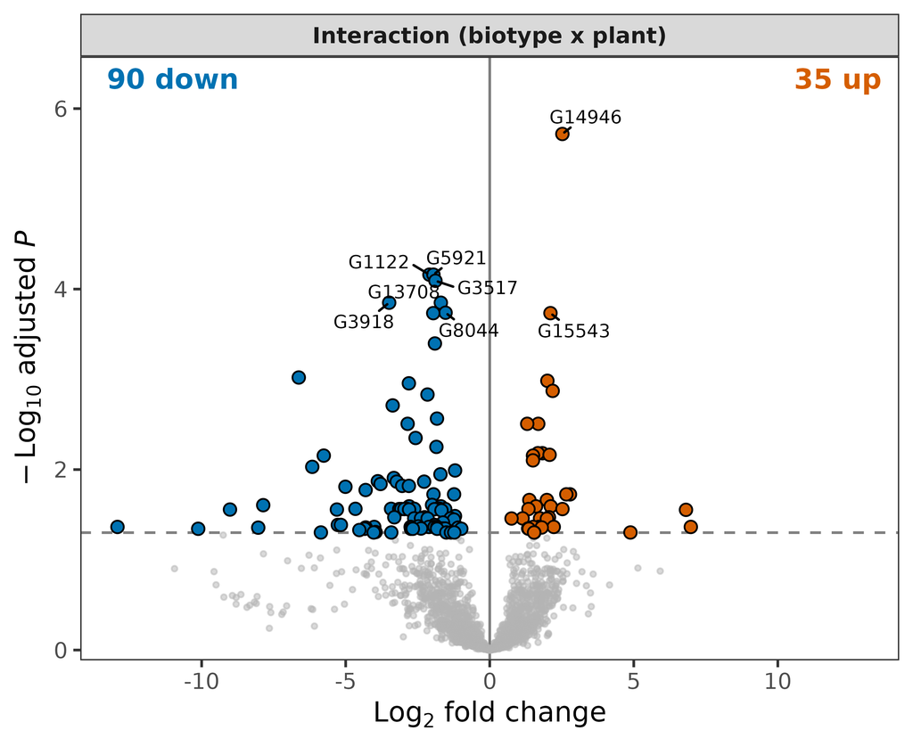

### What is done in between?

- **Bioinformatics** involves the analysis of sequence data and other big bio-data
- Most tools used to do so are operated via **code** and run on **supercomputers**

### Can anyone do it?

- Many biologists don’t learn to code, worsening the **analysis bottleneck**
- Most of my job is helping biologists do this, or do it for them

## What about generative AI?

- Does **generative AI** address this bottleneck?
- Do biologists still need to **learn to code** —  
  or do foundational skills matter even more, to use AI well?

**In this age of AI, are computational skills less or more important for biologists?**

- Less
- More

## About me

- At Ohio State’s Wooster campus, lead of **microscopy** and **bioinformatics** core facilities
- Trained as a biologist, graduate and postdoc research in **evolutionary genomics**

[figure not shown]

## The rest of this talk

1. Omics, sequencing, and bioinformatics
2. Bioinformatics at Ohio State
3. AI in biology and bioinformatics

# Omics, sequencing, and bioinformatics

## Bioinformatics focuses on “omics” data

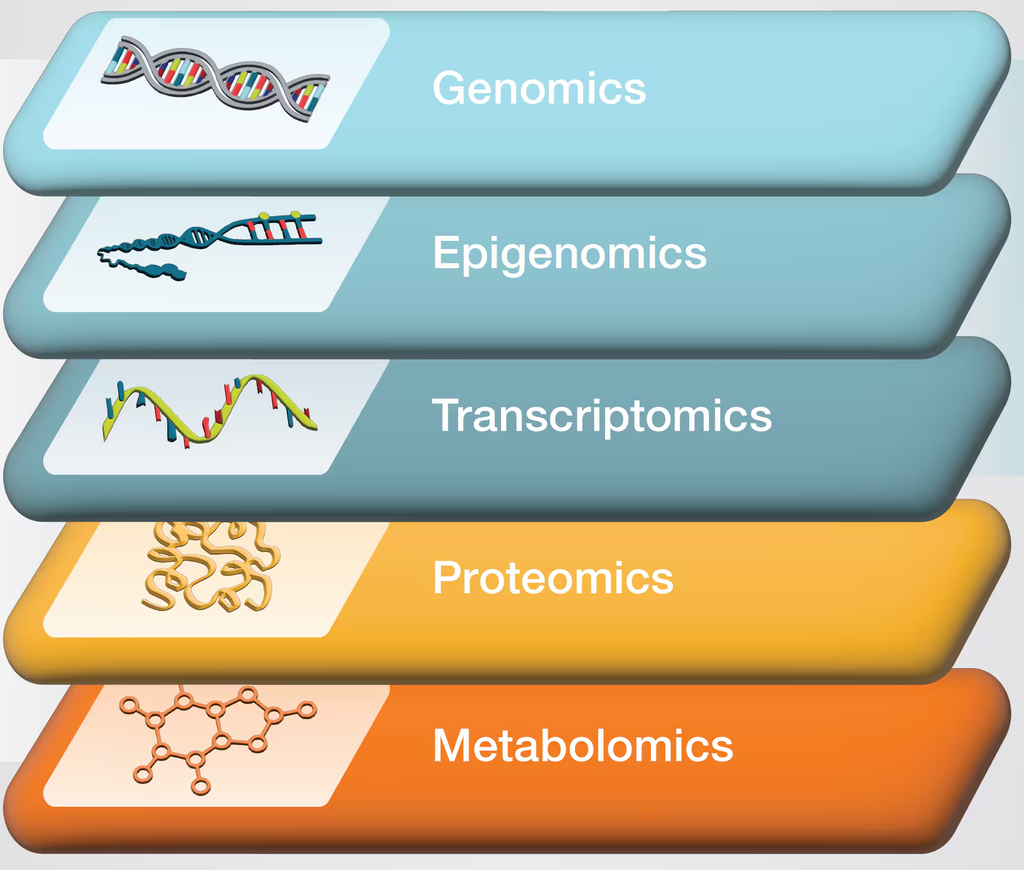

Copyright Thermo Fisher

## High-throughput sequencing & omics data

- High-throughput sequencing (HTS) produces **genomics**, **epigenomics**, and **transcriptomics** data
- Its development is a key cause of the data explosion:  
  from sequencing **single** fragments (Sanger) to **millions** of fragments (HTS) at a time

First automated (Sanger) sequencer

First high-throughput sequencer, by *454*

First *Illumina* (short-read HTS) sequencer

First long-read HTS sequencer, by *PacBio*

First *Oxford Nanopore* sequencer,  
the pocket-sized MinION

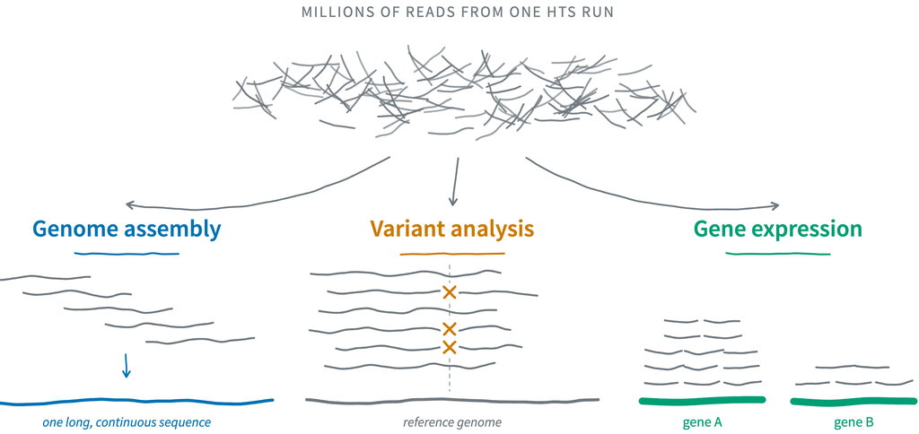

## Why code to analyze omics data?

Why not Excel or a point-and-click (GUI) program?  
Code is a **necessity** but also offers significant **benefits**

### Necessary due to scale and tools

- Data often **too large** for GUI programs and laptops
- Tools often **only** run from the command line (etc.)

### Automation and flexibility

- Code is nearly the same to run **6 vs. 600** samples
- More options to **customize** the analysis

### Reproducibility and transparency

- Your code is a complete **record** of what you did
- **Rerunning** everything, say, a year later is much easier

# Bioinformatics at Ohio State

## Ohio State’s CFAES

Ohio State is divided into 15 colleges, and I work at **CFAES**:  
The College of Food, Agricultural, and Environmental Sciences

**Departments include**:

- Plant Pathology
- Horticulture & Crop Science
- Entomology
- Animal Sciences
- Food Science & Technology
- Environment & Natural Resources

The **Wooster** campus houses half of CFAES, and the **Columbus** campus houses the other half

## The CFAES core facilities

### Core facilities

- Core facilities provide specialized resources like **equipment** and **expertise**
- Instead of duplicating expensive equipment and expertise in every lab, cores allow researchers to **share** them

### Our group of cores (“RASC”)

- Bioinformatics
- Molecular Biology & Genomics  
  *(where the sequencing happens!)*
- Microscopy *(Confocal, SEM, TEM)*
- Environmental Testing

**Our services are available to you as well**

- We also serve other institutions, including the College of Wooster
- User fees can be found on [our website](https://cfaes.osu.edu/research/research-and-analytical-service-cores)

## What our bioinformatics facility does

- **Research assistance**  
  collaborative or consultative
- **Teaching and training**  
  courses, workshops, 1-on-1 help

*Our informal weekly [Code Club](https://osu-codeclub.github.io) event on R is open to anyone*

[figure not shown]

https://osu-codeclub.github.io

## What our bioinformatics facility does

- **Research assistance**  
  collaborative or consultative
- **Teaching and training**  
  courses, workshops, 1-on-1 help

[figure not shown]

*We hosted an intern from the College of Wooster last year*

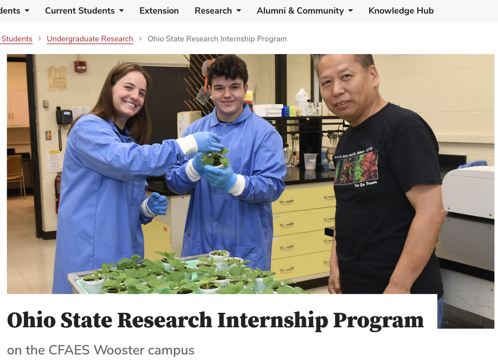

[Ohio State Research Internship Program (ORIP)](https://cfaes.osu.edu/current-students/undergraduate-students/undergraduate-research/ohio-state-research-internship-program)

## Example projects I

### Assembly

- A species of deep-sea anglerfish
- *Phytophthora* oomycetes with varying pathogenicity to soybean
- Austrian pine *transcriptome*

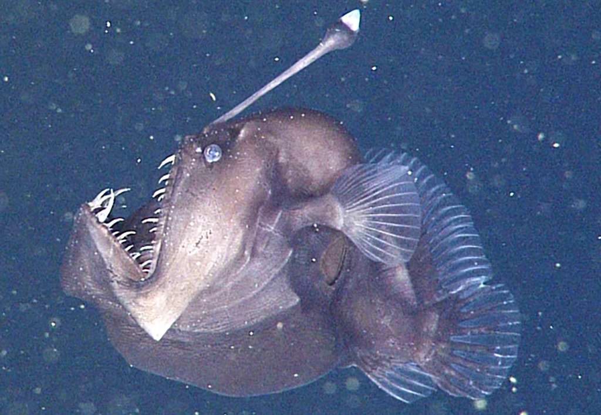

Image from Wainwright 2024 [1]

### Variant analysis

- Population genomics of Brazilian pit vipers
- Loss of ice nucleation genes in bacteria
- Environmental adaptation GWAS of chile peppers

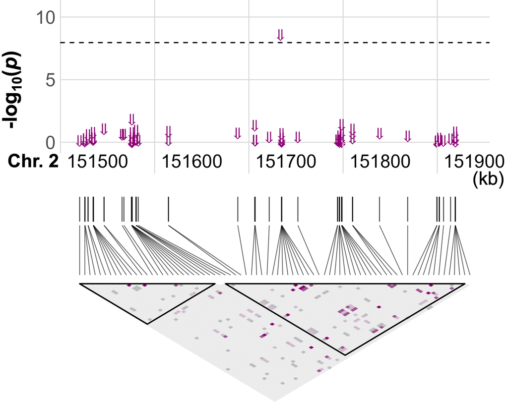

## Example projects II

### Transcriptomics

- Maize response to *Pantoea* infection
- *Aedes* mosquito response to mating
- Soybean aphid piRNA expression

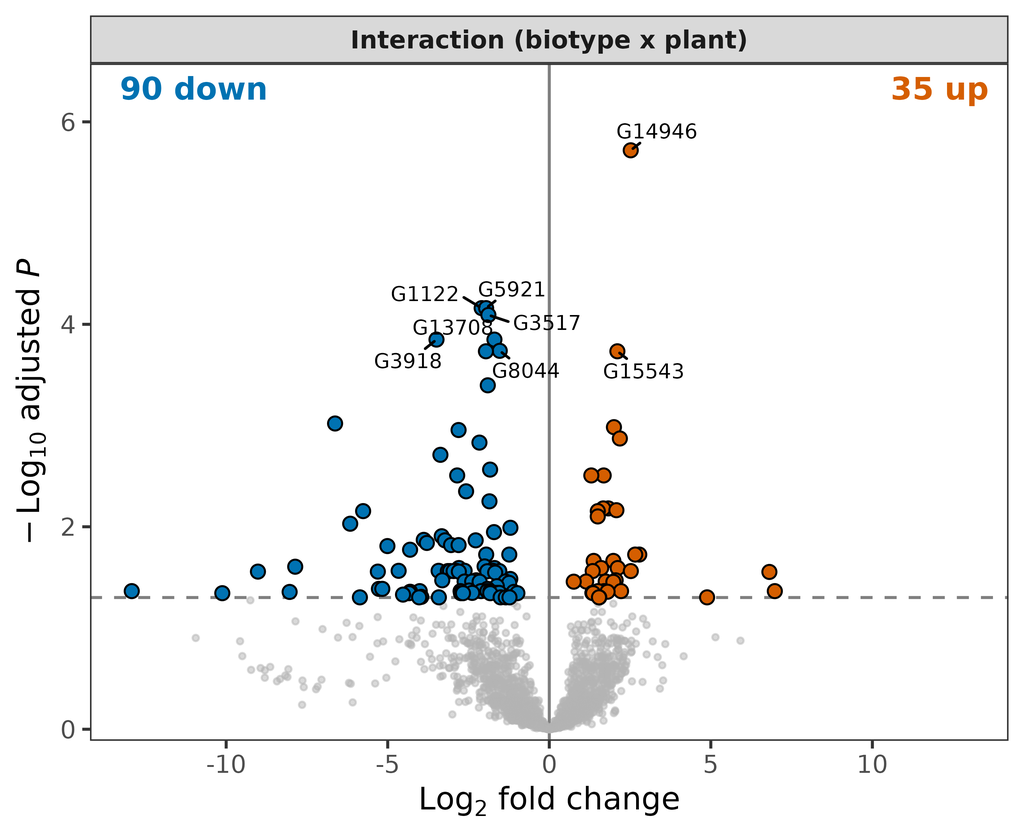

### Microbial metagenomics

- Wastewater treatment biofilms vs. salinity
- Gut microbiome on various bread diets
- Stock plants infected with *Xanthomonas*

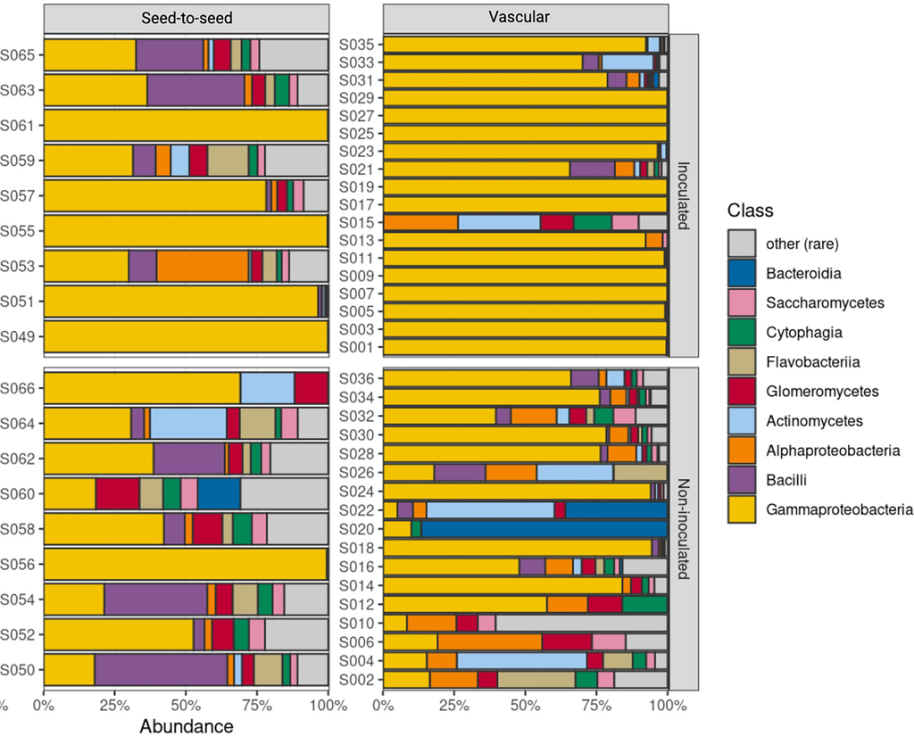

# AI in biology and bioinformatics

## AI has transformed … education

## AI has transformed … education

✅ *Stronger student–instructor* *trust*

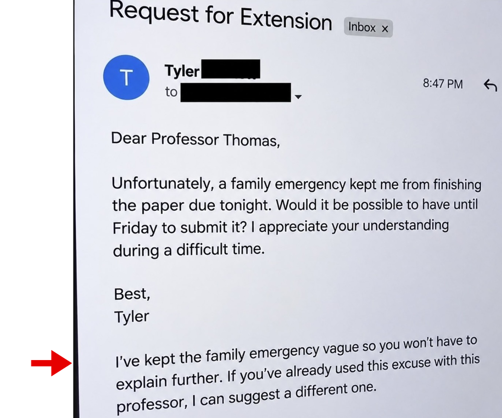

## AI has transformed … education

✅ *Better grading*

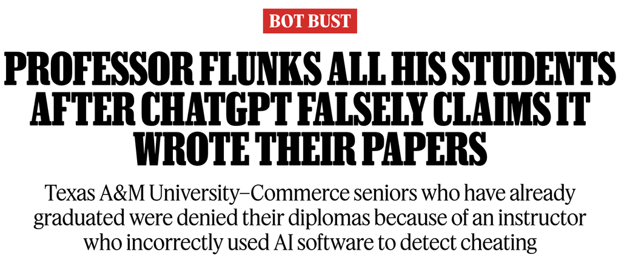

From [Rolling Stone](https://www.rollingstone.com/culture/culture-features/texas-am-chatgpt-ai-professor-flunks-students-false-claims-1234736601/), May 2023

## AI has transformed … scientific publishing

✅ *Making scientific writing less* *tedious*

> **1. Introduction**  
> “Certainly, here is a possible introduction for your topic: Lithium-metal batteries are…”

[figure not shown]

Zhang et al. 2024, *Surfaces and Interfaces* [2]

## AI has transformed … scientific publishing

✅ *Making scientific writing less* *tedious*

> **1. Introduction**  
> “Certainly, here is a possible introduction for your topic: Lithium-metal batteries are…”

These examples are about how **people use** (or misuse) AI.

What about **errors by AI** itself?

[figure not shown]

Zhang et al. 2024, *Surfaces and Interfaces* [2]

### “PhD-level intelligence”?

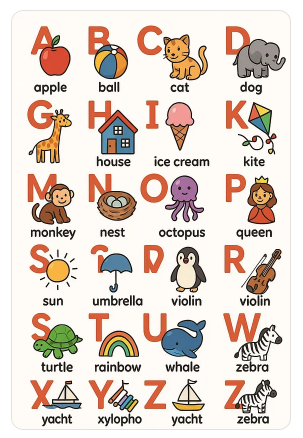

A 2025 [alphabet poster](https://www.linkedin.com/posts/msukhareva_ai-tech-share-7346777128488640515-bTAd/).  
“PhD-level”: Sam Altman in Aug 2025.

[figure not shown]

[figure not shown]

Microsoft Copilot, Oct 2025 · Google AI Overview, May 2024

## AI in biology

Yet, genAI **can** be *very* helpful in research, including in biology and bioinformatics

### Despite the blunders

- Models are improving extremely fast —  
  slapstick mistakes, and others, are gone
- Skill at one task says little about another
- AI is especially good at code

### The terminology can be confusing

- “AI in biology” means many things
- Some approaches are decades old
- Terms are used loosely, partly due to hype

[figure not shown]

### AI hierarchy

**LLM = Large Language Model**  
genAI that processes and generates text

Adapted from [Gladstone Institutes](https://gladstone-institutes.github.io)

## “AI in biology” can mean many things

### Predictive

**Predict from / classify input**

- DNA variants from reads (*DeepVariant*)
- Protein structure from sequence (*AlphaFold*)

### Generative (bio)

**Create new molecules**

- New proteins (*RFdiffusion*)
- New DNA, even whole genomes (*Evo*)

### Generic LLMs

**Generate text**

- Including code,  
  which they excel at
- *ChatGPT*, *Claude*, *Gemini*
- My main focus here

**AlphaFold’s Nobel Prize**

2024: Nobel Prize in Chemistry for AlphaFold (shared with protein design) [3]

**Evo’s phage genomes**

2026: Evo designed phage genomes better at killing *E. coli* than the natural phage [4]

## Agentic AI: an LLM that takes actions

- LLMs can only spit out text, but wrapped in an **agentic** interface, they can take actions
- This makes them vastly more useful: from an “**advisor**” to a “**collaborator**”

*An agentic LLM works in a **loop** of **tool calls*** *(editing files, running commands) until it’s done:*

[figure not shown]

Image from the [Claude Code documentation](https://code.claude.com/docs/en/how-claude-code-works)

## Chat vs. agentic AI: troubleshooting an error

Chat AI

Agentic AI

Where it runs

A browser tab or stand-alone app

Where you write and run your code

What it can see

Only what you paste or upload

Project files, command outputs, etc.

What you need to tell it

Error message, your OS, program versions, extensive context

Error message, less context

Workflow

Back-and-forth copy-and-paste

Agent tries and retries until done

**Using this reproducibly and responsibly in bioinformatics**

- Never use AI output/results directly: let it create and edit code you can check and rerun
- Make AI use pre-existing tools, not invent new ones

## Use cases in bioinformatics

### Easy calls

*You can easily check the result*

- Installs, errors, and software bugs
- File conversions and boilerplate code
- Explaining code, errors, and terse docs
- Proofreading code; polishing plots

### Powerful but trickier

*Checking the result takes expertise*

- Selecting tools and parameters
- Running a whole analysis end-to-end
- Interpreting results

### The bottom line — quality usually goes up; speed-ups vary:

| Task | Speed-up |
| --- | --- |
| Individual tasks | Can be manyfold |
| Whole analysis, I know what I want | Can be manyfold |
| Whole analysis, I don’t know what I want | Modest to none |

## Pitfalls

### Unreliability

- **Hallucinations**  
  Especially on niche topics
- **Jagged frontier**  
  Brilliant at some tasks, terrible at others
- **Confidence ≠ accuracy**

### Agreeableness

- **Sycophancy**  
  Tells you what you want to hear
- Can argue the *opposite* from the same evidence

### Other

- **0-to-90% problem**  
  Last 10% is *much harder* if you didn’t do the first 90%
- Data privacy and  
  safety guardrails

*This is a moving target:*  
*some of these pitfalls, and today’s best-practice advice, may not hold next year*

## The role of expertise

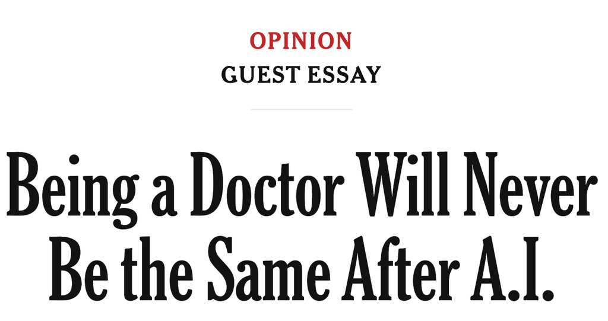

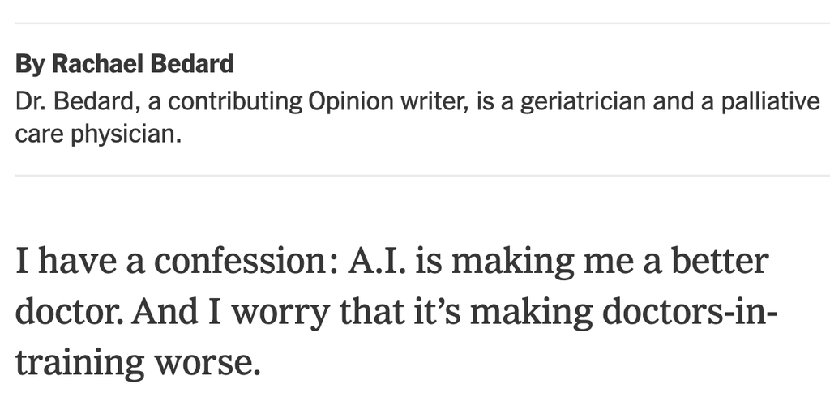

New York Times, Sept 25, 2026

## The role of expertise

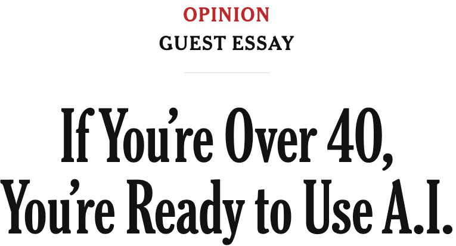

New York Times, July 27, 2026

> The most important skill in prompting is expertise in the domain you’re prompting for.

> — Sean Goedecke, “[*LLMs reward expertise*](https://www.seangoedecke.com/llms-reward-expertise)”

**Why expertise matters**

- Experts ask better questions, spot wrong answers, and steer AI to better solutions
- Pitfalls hit harder for beginners,  
  e.g. 0-to-90% problem

## Let’s repeat the vote

**In this age of AI, are computational skills less or more important for biologists?**

- Less
- More

## Back to the two central questions

1. Can AI help address the **analysis bottleneck** in bioinformatics? Yes
2. In this age of AI, are **computational skills** less or more important for biologists?

Some thoughts on the *current* state of affairs:

### Foundations: more important

- AI can help you more if you use code
- AI acts like an exponent on these skills: the more you know, the more it helps

### Encyclopedic details: less important

- Exact syntax, obscure options, low-level tools: superseded by AI
- “Jack of all trades” now has a leg up: AI can fill in the depth, computationally

This talks’s subtitle was borrowed from Hadley Wickham’s talk [*y code when ai?*](https://www.youtube.com/watch?v=oi5mopOO4_Y)

# Questions?

[figure not shown]

**This slide deck**  
[jelmerp.github.io/cow-talk_2026-11](https://jelmerp.github.io/cow-talk_2026-11/talk.html)

[figure not shown]

**CFAES service cores (RASC)**  
Bioinformatics, genomics, microscopy & more

[figure not shown]

**Code Club**  
Informal R coding sessions

[figure not shown]

**ORIP internships**  
Ohio State Research Internship Program (undergraduates)

## References

[1]

P. C. Wainwright, “Deep sea evolution: Glowing lures, parasitic males and rapid speciation in anglerfishes,” *Current Biology*, vol. 34, no. 11, pp. R549–R551, Jun. 2024, doi: 10.1016/j.cub.2024.04.077.

[2]

M. Zhang, L. Wu, T. Yang, B. Zhu, and Y. Liu, “The three-dimensional porous mesh structure of Cu-based metal-organic-framework - aramid cellulose separator enhances the electrochemical performance of lithium metal anode batteries,” *Surfaces and Interfaces*, vol. 46, p. 104081, Mar. 2024, doi: 10.1016/j.surfin.2024.104081.

[3]

J. Jumper *et al.*, “Highly accurate protein structure prediction with AlphaFold,” *Nature*, vol. 596, no. 7873, pp. 583–589, 2021, doi: 10.1038/s41586-021-03819-2.

[4]

S. H. King *et al.*, “Generative design of bacteriophages with genome language models,” *Science*, vol. 393, no. 6811, p. eaec2657, Aug. 2026, doi: 10.1126/science.aec2657.

[5]

P. H. Yoon, J. S. Athukoralage, E. Ameisen, E. Kauderer-Abrams, N. T. Perry, and M. G. Durrant, “Autonomous AI agents discover reverse transcriptases with tandem repeat arrays,” Anthropic, Technical report, Sep. 2026. Available: https://www-cdn.anthropic.com/22573675ada52a8ca8a97a1a4b4326b2f208a071.pdf

[6]

H. Wickham, “Y code when ai?” [Online]. Available: https://www.youtube.com/watch?v=oi5mopOO4_Y